# Creating a plot like the Economist in R

David Benson

The Economist uses a unique style for their visualisations which can be imitated easily in R. This short guide will show exactly how easy this can be.

The dataset used in this guide comes from Eurostat and is the quarterly GDP of the orginal 12 Eurozone countries from 1997 to 2016. The data uses current prices per million euro and is both seasonally and calendar adjusted.

### Installing, Loading and Reading

Firstly, it is important to install and load the necessary packages. ggplot2 is the package that creates the bar chart and ggthemes includes the Economist styling. We read the data in as a data frame for ggplot2 to work (first make sure you are in the same directory as the data).

```r
install.packages('ggplot2')
install.packages('ggthemes')
library(ggplot2)
library(ggthemes)
data <- data.frame(read.csv('data.csv'), row.names="Time")
```

### Analysis and Plotting

The means are calculated for each country using ‘colMeans’ and this is converted into a data frame.

```r
gdpMeans <- colMeans(data)
means <- data.frame(gdpMeans)
means
```

```
##        gdpMeans
## Bel   81558.235
## Ger  614959.176
## Ire   40419.923
## Gre   46135.104
## Spa  226039.054
## Fra  454113.006
## Ita  367130.379
## Neth 140234.158
## Aus   66987.056
## Por   39076.562
## Fin   42650.390
## Lux    8608.785
```

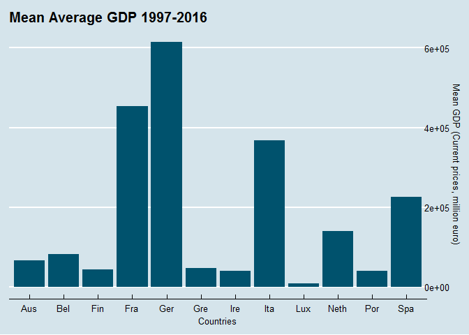

```r
economist <- ggplot(means, aes(x=rownames(means), y=means$gdpMeans)) + geom_bar(stat="identity",fill="#00526D") + labs(title="Mean Average GDP 1997-2016") + labs(x="Countries") + labs(y="Mean GDP (Current prices, million euro)") + guides(fill=FALSE) + theme_economist() + scale_colour_economist() +
  scale_y_continuous(position = "right")
economist
```

For fun, this graph has also been created with a similar procedure using styling like the Financial Times.

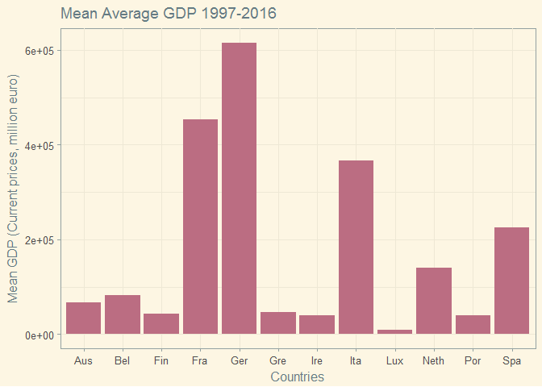

```r
financialTimes <- ggplot(means, aes(x=rownames(means), y=means$gdpMeans, fill=rownames(means))) + geom_bar(stat="identity",fill="#BB6D82") + labs(title="Mean Average GDP 1997-2016") + labs(x="Countries") + labs(y="Mean GDP (Current prices, million euro)") + guides(fill=FALSE) + theme_solarized() + scale_colour_solarized("blue")
financialTimes
```

## Final Words

Creating plots that look like those from proffessional newspapers and magazines are incredibly easy with R using ggplot2 and ggthemes. For more themes, check out https://github.com/jrnold/ggthemes.